# Molecularly Subtyping Embryonal Tumors - C19MC amplifications

Jo Lynne Rokita, Stephanie J. Spielman, and Jaclyn N. Taroni

2020

The purpose of this notebook is to clean copy number data related to C19MC amplifications in non-MB, non-ATRT embryonal tumors ([`AlexsLemonade/OpenPBTA-analysis#251`](https://github.com/AlexsLemonade/OpenPBTA-analysis/issues/251)).

Specifically, we are trying to identify Embryonal tumor with multilayered rosettes (ETMR), C19MC-altered tumors.

## Usage

This notebook can be run via the command line from the root directory of the repository with:

```
Rscript -e "rmarkdown::render('analyses/molecular-subtyping-embryonal/03-clean-c19mc-data.Rmd', clean = TRUE)"
```

## Set up

### Handling CI

```r
# Assigning params$is_ci to running_in_ci avoids a locked binding error
running_in_ci <- params$is_ci

# Are we testing? In case of a non 0/1 number, we recast as logical, and then
# ensure logical.
if (running_in_ci %in% c(0,1)) running_in_ci <- as.logical(running_in_ci)

# If not logical, need to throw an error here
if (!(is.logical(running_in_ci))) {
  stop("\n\nERROR: The parameter `is_ci` should be FALSE/TRUE (or 0/1).")
}
```

### Libraries and functions

```r
suppressPackageStartupMessages(library(tidyverse))
suppressPackageStartupMessages(library(ggbio))
```

We’re going to adapt code from the [`cnv-chrom-plot`](https://github.com/AlexsLemonade/OpenPBTA-analysis/tree/eadb78d9ef02d35ae06a88104b29b4d0325499a6/analyses/cnv-chrom-plot) module to plot chromosome 19.

```r
plot_chr19 <- function(cn_df, biospecimen_id) {
 # This function takes a seg data.frame and a biospecimen identifier and
 # returns a plot of the chromosome 19 segment mean for that biospecimen.
 # It fills missing seg.mean values with zeroes.
 #
 # Args:
 #   cn_df: data.frame in SEG format
 #   biospecimen_id: A Kids First Biospecimen ID used to filter cn_df
 #
 # Returns: essentially a barplot of the non-neutral segment means

  bsid_data <- cn_df %>%
    # For visualization purposes fill the missing seg.mean values with zeroes
    tidyr::replace_na(list(seg.mean = 0)) %>%
    # Reformat the chromosome variable to drop the "chr"
    dplyr::mutate(chrom = factor(gsub("chr", "", chrom),
                                 levels = c(1:22, "X", "Y"))) %>%
    # Only look at chr19 in the relevant sample
    filter(ID == biospecimen_id,
           chrom == 19) %>%
    # Make Del/Amp variable
    dplyr::mutate(Type = dplyr::case_when(
      seg.mean < 0 ~ "Del",
      seg.mean > 0 ~ "Amp",
      seg.mean == 0 ~ "Neutral"
    ))

  # Turn into a GRanges for easier mapping
  bsid_ranges <- GenomicRanges::GRanges(
    seqnames = bsid_data$chrom,
    ranges = IRanges::IRanges(
      start = bsid_data$loc.start,
      end = bsid_data$loc.end
    ),
    score = bsid_data$seg.mean,
    mcols = bsid_data$Type
  )

  # Map this on a plot
  bsid_plot <-
    ggbio::autoplot(bsid_ranges,
                    ggplot2::aes(y = score, fill = mcols),
                    geom = "bar") +
    ggplot2::theme_bw() +
    ggplot2::ylim(c(-2, 2)) +
    colorblindr::scale_fill_OkabeIto(name = "Type") +
    ggplot2::labs(
      title = paste(biospecimen_id, "chr19"),
      y = "segment mean"
    )

  return(bsid_plot)
}
```

### Directories

```r
results_dir <- "results"
data_dir <- file.path("..", "..", "data")
```

### Read in Files

```r
# full clinical file
histologies_file <- file.path(data_dir, "pbta-histologies-base.tsv")
histologies_df <- read_tsv(histologies_file,
                           col_types = cols(
                             molecular_subtype = col_character()
                           ))

# copy number consensus file (analysis file)
cn_consensus_seg <- file.path(data_dir,
                              "pbta-cnv-consensus.seg.gz")
# file that contains the biospecimen IDs that met criteria for subtyping
biospecimen_file <- file.path(results_dir,
                              "biospecimen_ids_embryonal_subtyping.tsv")

# get biospecimen ids as a vector rather than data frame
biospecimen_ids <- read_tsv(biospecimen_file) %>%
  pull(Kids_First_Biospecimen_ID)

# we'll filter to only the relevant biospecimens for the copy number alteration
# data that is committed to the repository
cn_consensus <- read_tsv(cn_consensus_seg) %>%
  filter(ID %in% biospecimen_ids)
```

### Output file

```r
output_file <- file.path(results_dir, "cleaned_chr19_cn.tsv")
```

## Look at copy number alterations on chr 19

We’re interested in focal amplification of C19MC (miRNA cluster on chr19) for the **ETMR, C19MC-altered** subtype.

```r
chr19_cn_df <- cn_consensus %>%
  filter(chrom == "chr19",
         seg.mean > 0)

chr19_cn_df
```

| ID | chrom | loc.start | loc.end | num.mark | seg.mean | copy.num |
| --- | --- | --- | --- | --- | --- | --- |
| BS_69VS8PS1 | chr19 | 53653251 | 54427564 | NA | 1.621000 | 5 |
| BS_K07KNTFY | chr19 | 53641206 | 54049403 | NA | 1.274914 | 12 |
| BS_K07KNTFY | chr19 | 54138551 | 54427104 | NA | 1.358318 | 12 |
| BS_TE8QFF7T | chr19 | 53659169 | 54424398 | NA | 1.760578 | 8 |

These are not within the ranges from @sjspielman provided [here](https://github.com/AlexsLemonade/OpenPBTA-analysis/pull/401/files#diff-77e96177f89b99ad2b1f0fe51ec5c22eR110):

```
## From UCSC Genome Brower, these are positions corresponding to 19q13.41 (C19MC region)
c19mc_region <- "19q13.41"
c19mc_start  <- 51400001
c19mc_end    <- 53600000
```

But they do overlap with coordinates from other papers. These are from Jo Lynne Rokita in [this comment](https://github.com/AlexsLemonade/OpenPBTA-analysis/pull/458#issuecomment-581050051).

From [Bentwich et al. *Nature Genetics.* 2005.](https://doi.org/10.1038/ng1590):

> Cluster on chromosome 19 located at positions 58,861,745–58,961,404 (HG17) and comprising 54 microRNA genes grouped into four families on the basis of hairpin sequence similarity.

| version | chr | start | end |
| --- | --- | --- | --- |
| hg17 | chr19 | 58861745 | 58961404 |
| hg19 | chr19 | 54169933 | 54269592 |
| hg38 | chr19 | 53666679 | 53766338 |

and from [Bortolin-Cavaillé et al. *NAR.* 2009.](https://dx.doi.org/10.1093%2Fnar%2Fgkp205):

> Schematic representation of the ∼100-kb long C19MC (HG18: 58 860 000–58 962 300) mapping at human chromosome 19q13.41

| version | chr | start | end |
| --- | --- | --- | --- |
| hg18 | chr19 | 58860000 | 58962300 |
| hg38 | chr19 | 53664934 | 53767234 |

### Visualization

For visualization purposes, we are filling in the missing `seg.mean` values with zeroes.

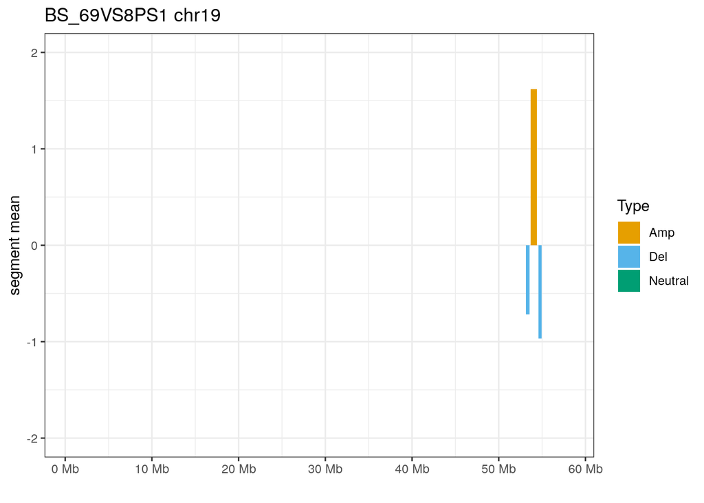

```r
if (!(running_in_ci)) {
  plot_chr19(cn_df = cn_consensus,
             biospecimen_id = "BS_69VS8PS1")
}
```

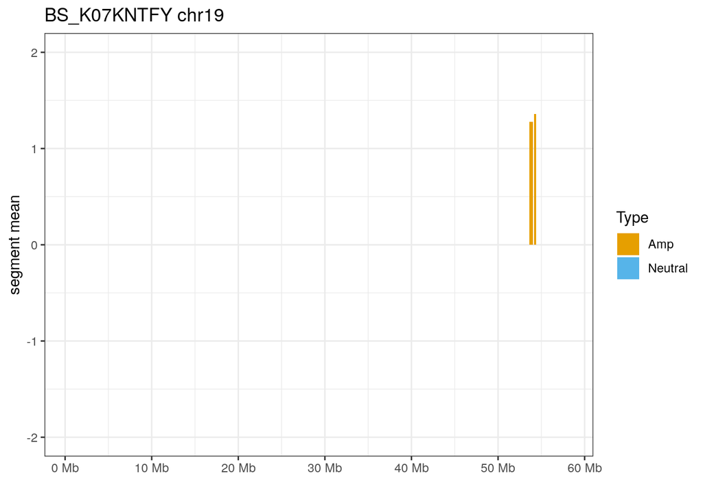

```r
if (!(running_in_ci)) {
  plot_chr19(cn_df = cn_consensus,
             biospecimen_id = "BS_K07KNTFY")
}
```

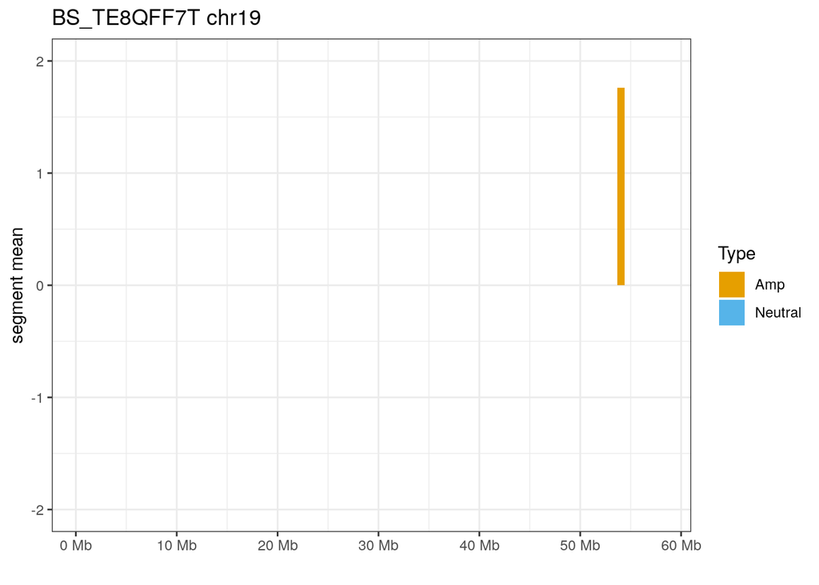

```r
if (!(running_in_ci)) {
  plot_chr19(cn_df = cn_consensus,
             biospecimen_id = "BS_TE8QFF7T")
}
```

### Generate cleaned table for joining to fusion and expression data

The copy numbers in all of the above cases are high - we’ll simplify the column name to `chr19_amplification`.

```r
# get a data.frame of the relevant WGS biospecimen_ids
wgs_ids <- intersect(histologies_df %>%
                       filter(experimental_strategy == "WGS") %>%
                       pull(Kids_First_Biospecimen_ID),
                     biospecimen_ids) %>%
  as.data.frame(stringsAsFactors = FALSE) %>%
  rename(Kids_First_Biospecimen_ID = ".")

chr19_cn_df <- chr19_cn_df %>%
  mutate(chr19_amplification = "Yes") %>%
  select(ID, chr19_amplification) %>%
  right_join(wgs_ids, by = c("ID" = "Kids_First_Biospecimen_ID")) %>%
  replace(is.na(.), "No")
```

Write to file.

```r
chr19_cn_df %>%
  rename(Kids_First_Biospecimen_ID = ID) %>%
  write_tsv(output_file)
```